# 1.4 Preprocessing techniques for spatially correlated data

code

share

► [Convolutional Networks](https://jermwatt.github.io/mlrefined/index.html)  
1.4 Preprocessing techniques for spatially correlated data

In this Section we describe popular pre-processing techniques for image, video, and other spatially correlated data. These techniques help normalize such datasets, often substantially improving our ability to train supervised learners.

## 1.4.1 Contrast normalization

Contrast normalization is a standard pre-processing technique applied to almost all image-based datasets. It simply involves *standard normalizing each image in a dataset*, that is subtracting its mean value and dividing off its standard deviation. This helps adjust for *contrast differences*. Note this procedure is done prior to any *feature-wise normalization technique* like the simple standard normalization, PCA spherering, or ZCA sphereing (see below for further details).

We almost never want an image-based supervised learner to be sensitive to contrast, since this would make natural image based supervised learning tasks like e.g., object detection much more difficult to solve (as detailed with simple examples in Section 14.1). In other words, contrast normalization helps our learners treat all images equally by normalizing their average intensity. Below we show an example image on the left and its contrast normalized version on the right.

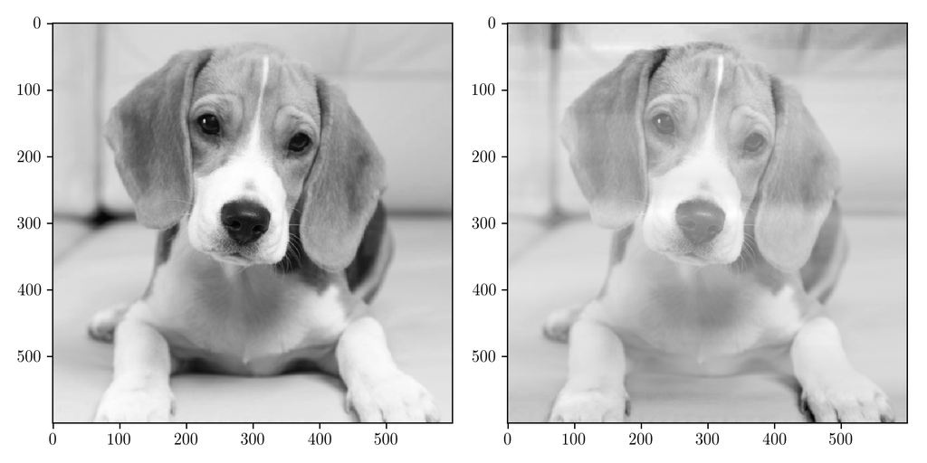

## 1.4.2 Feature scaling by Zero Phase Component Analysis (ZCA) sphereing

In Chapters 8 - 10 we saw how the simple idea of *standard normalizing* the input of a supervised learning dataset could drastically improve the learning ability of a zero or first order local optimization technique by improving the contours of any associated supervised cost function. Then in Chapter 11 we saw the natural evolution of this idea - PCA sphereing - could help even further improve the nature of a supervised cost function, allowing for even easier learning. In this Section we discuss a natural evolution of PCA sphereing - called *Zero Phase Component (ZCA) sphereing*. In re-alligning the input features of a given dataset with the coordinate axes PCA sphereing can completely destroy the local spatial / feature correlation of datatypes like images, video, etc., ZCA sphereing is designed specifically to deal with this issue and builds on its PCA predecessor by aiming to preserve the local correlation in a dataset's input. Because convolutional networks are specifically designed to extract spatially local information to improve supervised learning ZCA is often used as the normalization procedure prior to training a convnet on images / video / etc.,

The PCA-based sphereing detailed in Chapter 11 is generally applicable to any generic kind of data. However in the case of images, videos, and other types of data that has inherent local *spatial correlation* structure (e.g., in an image pixels near one another are highly correlated in terms of the intensity values) we often look to leverage this special structure to improve the generalizability of a trained supervised learner. For example in the case of image-data a carefully designed extensions of the supervised learning framework we have seen thus far - e.g., *edge detectors* more generally a *convolutional network* - are built specifically to leverage the spatial correlation in an image. Because of this, while we would still like to employ some sort of data normalization (an important engineering factor we always aim to employ in practice, as it greatly quickens the training process), we need to make sure that our data-normalization procedure will not destroy the spatial correlation we aim to explicitly leverage via e.g., edge detectors or convolutional operations. Does PCA-sphereing fit this bill?

To find out we perform PCA-sphereing on a set of standard handwritten digits - a random subset of 5,000 the MNIST dataset each 28x28 pixels in length/width. Because images are visual pieces of data we can compare data points visually before and after the PCA-sphereing process.

In the next cell we load in this dataset, and plot a sample of the MNIST dataset.

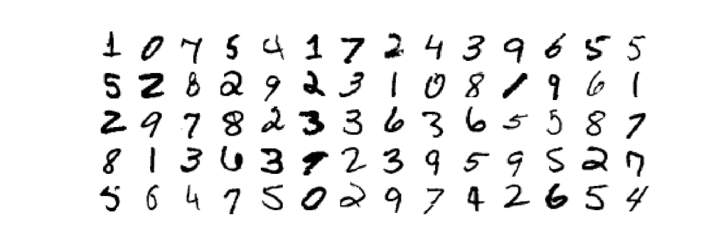

Below we show the result of standard normalizing a batch of these hand written digits. Notice how this produces edge-based artifacts! This will create potential problems with our edge-based convnets.

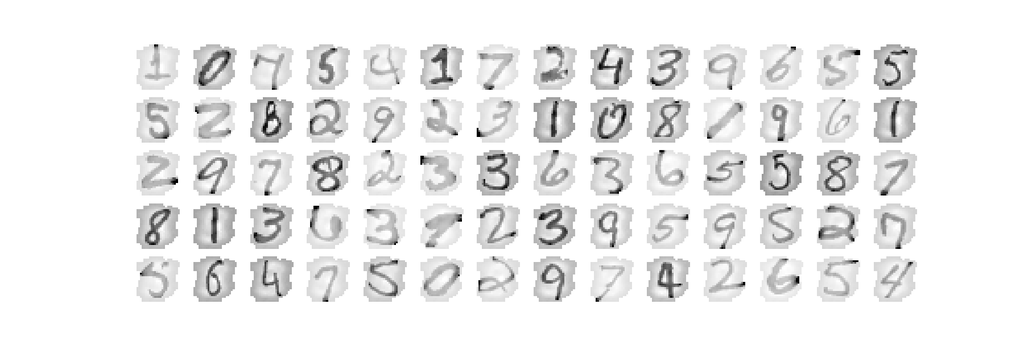

Now we perform PCA-sphereing on this handwritten digit dataset, and plot the resulting PCA-sphered data. Note: these are the same data points (transformed by the sphereing process, of course) we plotted above.

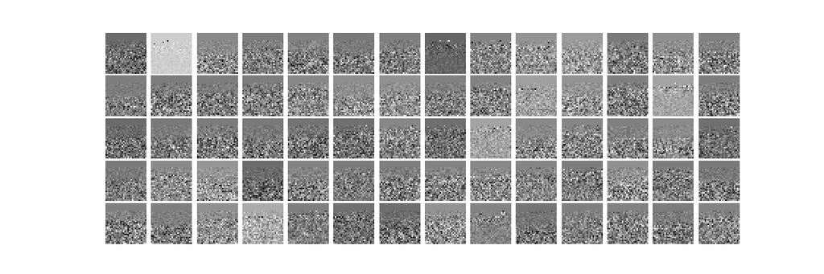

In this instance PCA-sphereing completely destroys the spatial structure of the original images - none of the original numbers are visible in these transformed versions. This phenomenon is true more generally: PCA-sphereing tends to destroy the spatial correlation of images, video, etc., What about the sphereing process we have applied is responsible for this?

As detailed in the previous Example, in terms of the actions we perform on the data itself with PCA-sphereing (or whitening) we:

- **rotate and reflect** by multiplying the data by $\mathbf{V}^T$ (where $\mathbf{V}$ is the set of eigenvectors of the data's covariance matrix) the data so that its largest orthogonal directions of variance align with the coordinate axes (this is done by the standard PCA transformation)
- **normalize** these coordinate axes by dividing by their individual standard deviations by multiplying the rotated/reflected data by $\mathbf{D}^{-^1/_2}$, the diagonal matrix of inverted square roots of the eigenvalues of the data's covariance matrix (this extra bit of normalization added to the PCA transformation to makes it the PCA-sphereing operation)

Both of these actions contribute to the destruction of spatial correlation - but it is the **rotation / reflection** component that is by far the greater culprit. We can get a visceral sense of this fact with our current dataset by simply applying the standard PCA transform - which will rotate / reflect the space so that the largest directions of variance coincide with the coordinate axes - without normalizing the result (which led to the PCA-sphereing result above). We do this in the next cell, and plot the resulting transformed images.

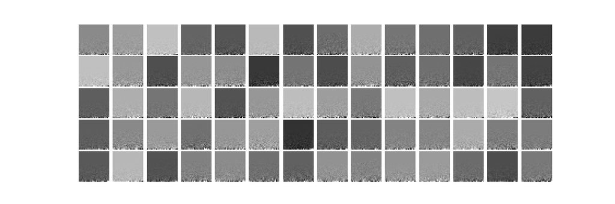

As we can see in the examples plotted above, the rotation / reflection from PCA transformation utterly - created by multiplying our data by $\mathbf{V}^T$ - utterly destroys the spatial correlation structure of our images, a phenomenon that is true more generally speaking for other image datasets as well. What can we do if we would still like the added optimization-boosting benefit of PCA-sphereing normalization but do not want to destroy the spatial correlation of our input data by rotating / reflecting it? Well if indeed the rotation / reflection is producing the greatest challenge in terms of maintaining the spatial correlation of our data, why don't we simply rotate / reflect our dataset back to its original orientation after we finish sphereing it (i.e.,normalizing it along its largest orthogonal directions of variance)? Since we know that it multiplication by $\mathbf{V}^T$ that produces the original rotation / reflection, multiplying by PCA-sphered data by $\left(\mathbf{V}^T\right)^{-1} = \mathbf{V}^{\,}$ (where the equality follows from the fact that $\mathbf{V}$ is an orthogonal matrix) will return the sphered data to its original orientation in the space. This is illustrated in the Figure below.

[figure not shown]

**Figure 2:** *ZCA-sphereing illustrated.*

Since our PCA-sphered transformation of the input data took the form $\mathbf{S}^{\,} = \mathbf{D}^{-^1/_2}\mathbf{V}^T\mathbf{X}^{\,}$ this re-rotation/reflection gives us the related formula

\begin{equation} \text{(ZCA-sphered data)}\,\,\,\,\,\,\,\,\, \mathbf{Z}^{\,} = \mathbf{V}\mathbf{S} = \mathbf{V}\mathbf{D}^{-^1/_2}\mathbf{V}^T\mathbf{X}^{\,}. \end{equation}

For historical reasons this re-rotated version of our PCA-sphered data is often referred to as *Zero-phase Component Analysis (ZCA) sphereing*.

We implement ZCA-sphereing in the next cell.

```python
# ZCA-sphereing - use ZCA to normalize input features
def ZCA_sphereing(x,**kwargs):
    # Step 1: mean-center the data
    x_means = np.mean(x,axis = 1)[:,np.newaxis]
    x_centered = x - x_means

    # Step 2: compute pca transform on mean-centered data
    d,V = PCA(x_centered,**kwargs)

    # Step 3: divide off standard deviation of each (transformed) input,
    # which are equal to the returned eigenvalues in 'd'.
    stds = (d[:,np.newaxis])**(0.5)
    normalizer = lambda data: np.dot(V, np.dot(V.T,data - x_means)/stds)

    # create inverse normalizer
    inverse_normalizer = lambda data: np.dot(V,np.dot(V.T,data)*stds) + x_means

    # return normalizer
    return normalizer,inverse_normalizer
```

With our ZCA-sphereing implementation written we can now transform the original centered dataset using it and examine the results.

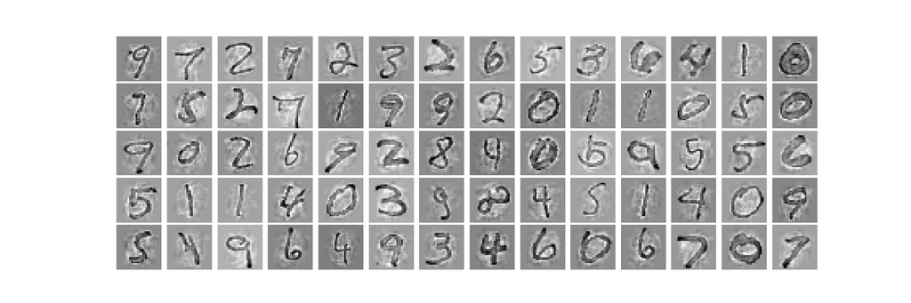

```python
# create ZCA sphereing normalizer and normalize data
zca_sphere,inverse_sphere = ZCA_sphereing(x)
x_sphered = zca_sphere(x)

# plot ZCA-sphered data
unsuplib.PCA_functionality.show_images(x_sphered)
```

What a difference! Indeed it was the rotation/reflection of PCA that destroyed most of the spatial correlation, since these ZCA-sphered images retain much of the spatial correlation present in their original versions. Now we have the best of both worlds: a global normalization scheme (that will help speed up training) that retains the spatial structure of data leveraged e.g., by edge detectors and convolution operations.

© This material is not to be distributed, copied, or reused without written permission from the authors.